# Practical 1: Amami rabbit Closed CMR

Student handout summarising the data

Script last run on 2021-11-08

Note that you are not allowed to use the figures in this document within your management plan.

# Reminder of closed CMR models

The aim of closed CMR models is to estimate population size. To do so, we need to know how many individuals we failed to capture. Given we know how many animals we *did* capture, we can add these two values together to get an estimate of total population size.

However, to estimate the number of individuals we failed to capture, we need to know what the capture probability was. If we know how likely we were to capture an animal, we know how *unlikely* we were to *not* capture an animal.

Closed CMR models estimate both the number of animals we did not capture (referred to as $f_0$, which stands for the frequency of animals, $f$, which were never capture $0$), in combination with the capture probability ($p$).

Given there may be a variety of processes that determined if an animal entered our trap or not (just like there may be multiple processes influencing your choice to drink coffee or not this morning), we have a suite of models that each represent different processes. These models include the fundamental forms:

- $M_o$, which posits that capture probability is best explained as a single, constant value (the Null model).
- $M_t$, which posits that the probability of capture varies over time.
- $M_b$, which posits that the probability of capturing an animal changes once it has been captured (e.g., trap happy or trap shy).

Note that these are only the fundamental models. They can be combined to propose, e.g., that there is a behaviour effect ($M_b$), that changes over time ($M_t$).

See the [practical video](https://abdn.cloud.panopto.eu/Panopto/Pages/Viewer.aspx?id=41c148c9-d2a1-4c90-8727-ac8e00ccf03a) for guidance on using `MARK` or for more information.

# Details of data collection

Beginning on the 3rd of July 1965, a capture-mark-recapture trapping session, lasting three days, occurred across the Amami island in a selection of sites known to have Amami rabbits present. Traps were baited with potato and carrots and were checked once every 24 hours. Researchers did not record any additional information.

The same data collection methodology was employed in 1983 in the same location.

# Capture histories

## 1965

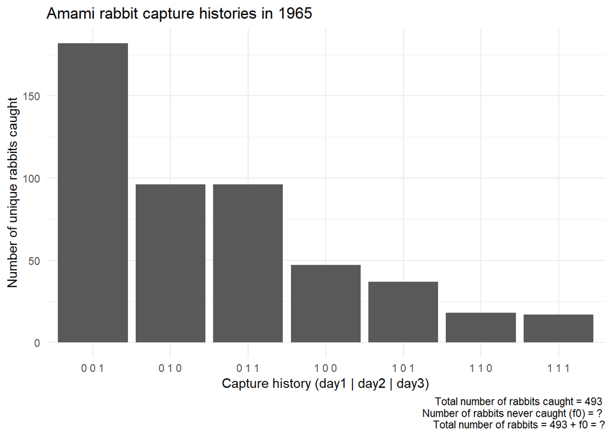

## 1983

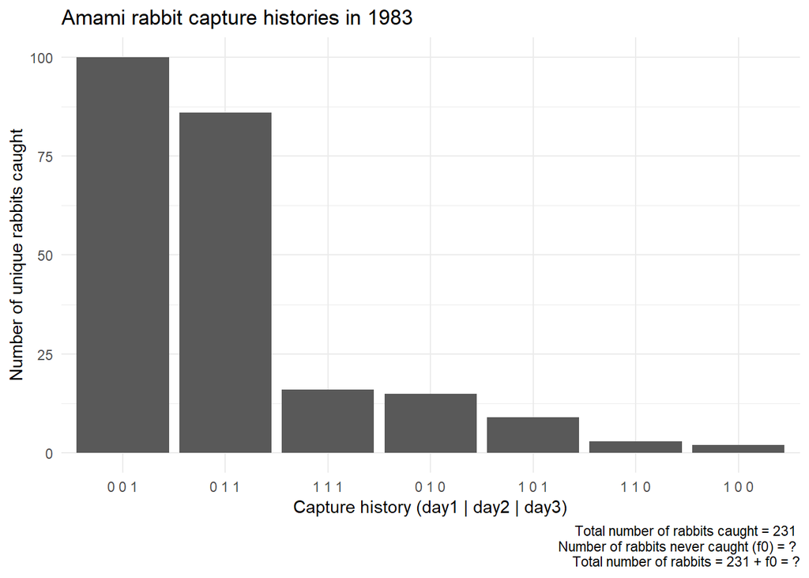

### One year olds

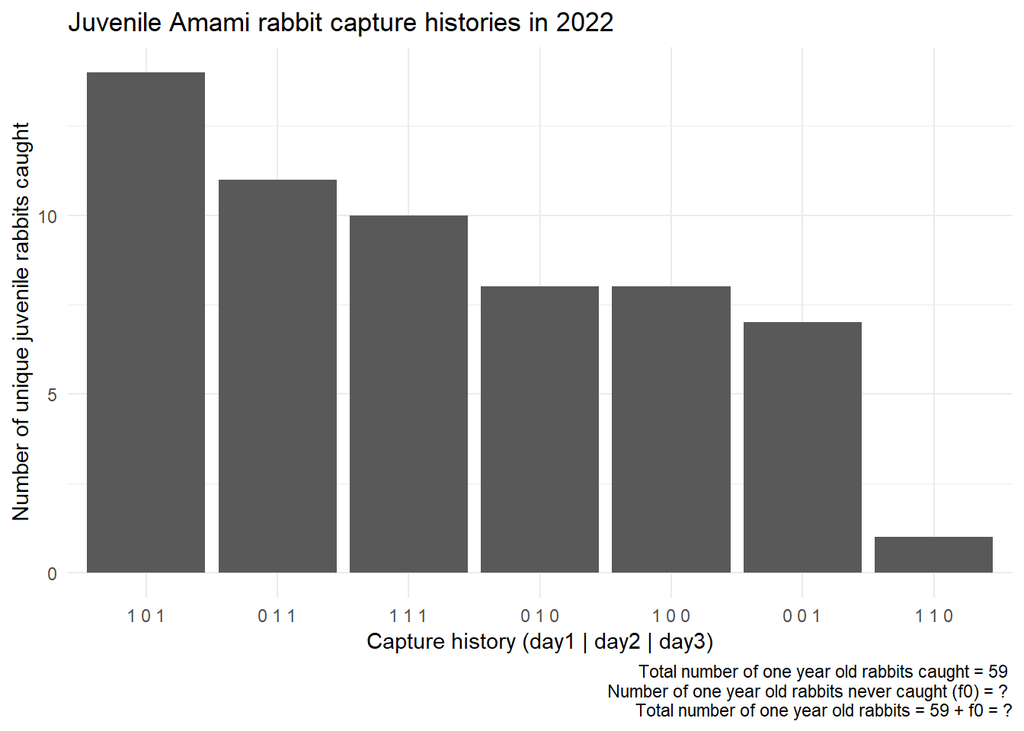

### Two year olds

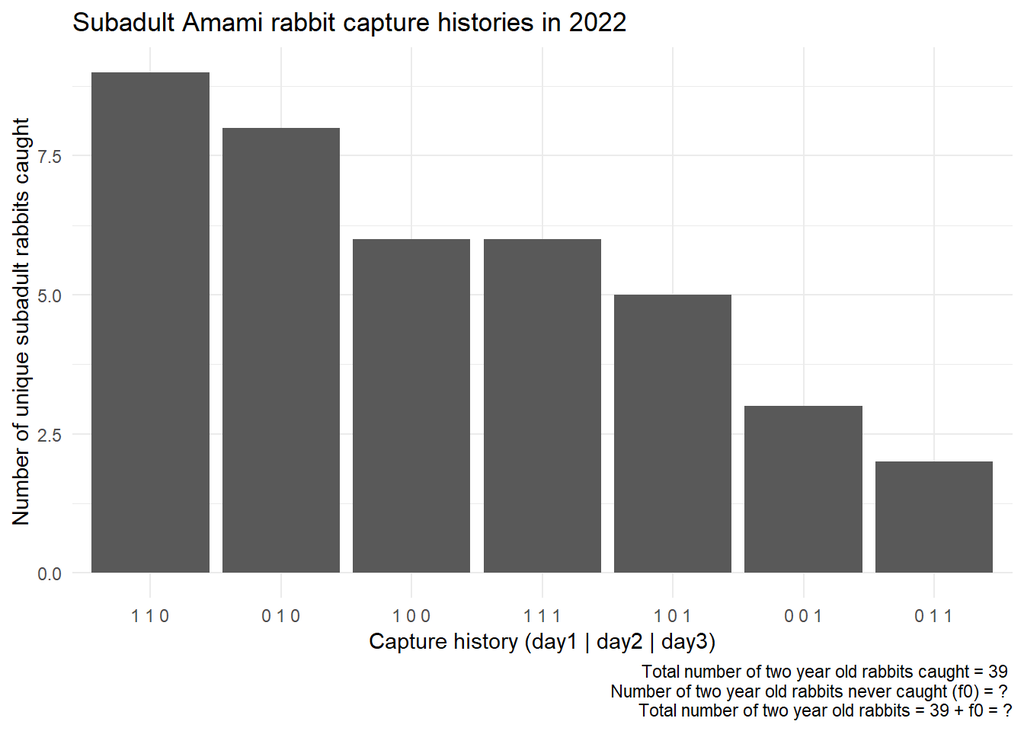

### Adults

[figure not shown]